# `prefviz`

## A visualisation toolkit for preferential election data

#### Linh Ngo, supervised by Dianne Cook, Damjan Vukcevic

[figure not shown]

## Preferential data captures rankings, not just first choices

> Preferential data record how people rank alternatives, not just which option they choose first.

**Common contexts:**

- Elections — voters rank candidates
- Consumer surveys — rank products
- Food research — rank dishes, wines, flavours

[figure not shown]

Australian ballot paper

# Part 2

**Motivation**

## Preferential data comes in many shapes…

**Wide** - one row per voter

| Member | tamago (egg) | ebi (shrimp) | anago (sea eel) |
| --- | --- | --- | --- |
| Alice | 1 | 2 | 3 |
| Ben | 3 | 1 | 2 |
| Carla | 2 | 3 | 1 |

**Long** - one row per voter–item pair

[output not shown]

**PrefLib** - encodes all items + a lot more metadata

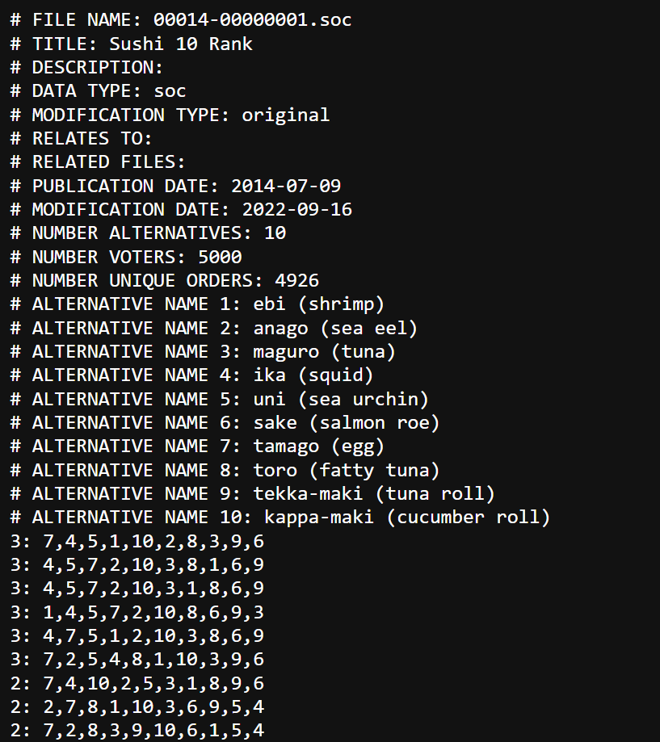

## And ideally, we want their shapes to be all the same

```r
sushi_data <- prefio::read_preflib(
  "00014 - sushi/00014-00000001.soc",
  from_preflib = TRUE
)
```

| preferences | frequency |
| --- | --- |
| [tamago (egg) > sake (salmon roe) > ika (squid) > uni (sea urchin) > ebi (shrimp) > kappa-maki (cucumber roll) > anago (sea eel) > toro (fatty tuna) > maguro (tuna) > tekka-maki (tuna roll)] | 3 |
| [ika (squid) > tekka-maki (tuna roll) > uni (sea urchin) > tamago (egg) > anago (sea eel) > kappa-maki (cucumber roll) > maguro (tuna) > toro (fatty tuna) > ebi (shrimp) > sake (salmon roe)] | 3 |
| [ika (squid) > tekka-maki (tuna roll) > uni (sea urchin) > tamago (egg) > anago (sea eel) > kappa-maki (cucumber roll) > maguro (tuna) > ebi (shrimp) > toro (fatty tuna) > sake (salmon roe)] | 3 |
| [ebi (shrimp) > maguro (tuna) > ika (squid) > uni (sea urchin) > tamago (egg) > anago (sea eel) > kappa-maki (cucumber roll) > toro (fatty tuna) > sake (salmon roe) > tekka-maki (tuna roll)] | 3 |
| [ika (squid) > tekka-maki (tuna roll) > tamago (egg) > uni (sea urchin) > ebi (shrimp) > anago (sea eel) > kappa-maki (cucumber roll) > maguro (tuna) > toro (fatty tuna) > sake (salmon roe)] | 3 |

## Compare and constrast a large number of preference sets

*First-preference votes for ALP, LNP, and Other - 2025 Australian House of Representatives election*

*…150 rows total*

| Electorate | ALP | LNP | Other |
| --- | --- | --- | --- |
| Adelaide | 0.46 | 0.24 | 0.29 |
| Aston | 0.37 | 0.38 | 0.25 |
| Ballarat | 0.42 | 0.29 | 0.29 |
| Banks | 0.36 | 0.39 | 0.24 |
| Barker | 0.22 | 0.50 | 0.28 |
| Barton | 0.47 | 0.24 | 0.29 |

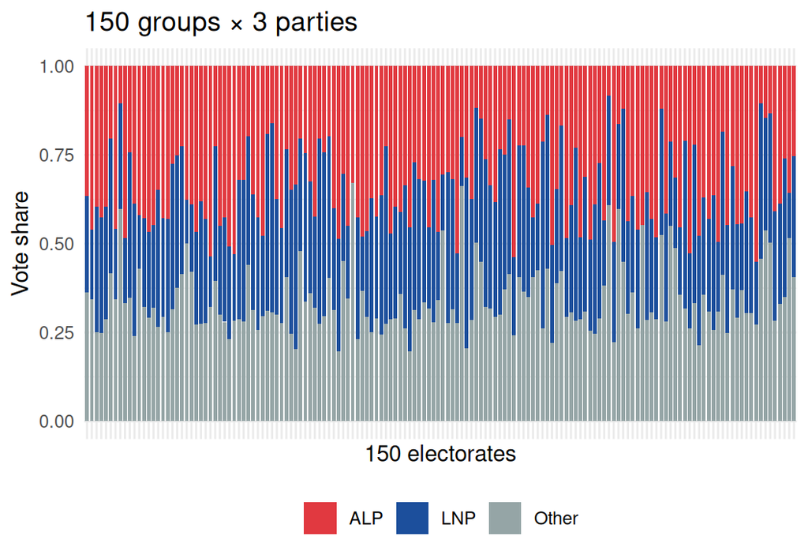

# Part 4

**Case study: 2025 Australian House of Representatives**

## 2025 Australian House of Representatives

**The data:**

- 150 electoral divisions, 28 parties, 6 parties won seats
- Major parties: **Labor (ALP)** & **Liberal–National (LNP)**
- Growing interest: **Greens (GRN)** & **Independents (IND)**

**Three questions this case study explores:**

1. How is the first-preference vote distributed across the two major parties across 150 electorates?
2. For selected electorates, how do preference shares shift through IRV counting rounds?
3. What additional structure is revealed when Greens and Independents are separated from “Others”?

## Transform the data

**Raw data**

```r
prefviz::aecdop_2025 |>
  select(DivisionNm, CountNumber, PartyAb,
         CalculationType, CalculationValue, Elected) |>
  filter(CalculationType == "Preference Percent") |>
  head()
```

```
# A tibble: 6 × 6
  DivisionNm CountNumber PartyAb CalculationType    CalculationValue Elected
  <chr>            <dbl> <chr>   <chr>                         <dbl> <chr>
1 Bean                 0 LP      Preference Percent             23.0 N
2 Bean                 0 IND     Preference Percent             26.4 N
3 Bean                 0 GRN     Preference Percent              9.5 N
4 Bean                 0 ALP     Preference Percent             41.0 Y
5 Bean                 1 LP      Preference Percent             23.3 N
6 Bean                 1 IND     Preference Percent             31.0 N
```

**Transformed data**

```r
pref25_2d <- dop_transform(
  data              = aecdop_2025,
  key_cols          = c(DivisionNm, CountNumber),
  value_col         = CalculationValue,
  item_col          = PartyAb,
  winner_col        = Elected,
  winner_identifier = "Y"
)
```

```
# A tibble: 976 × 6
   DivisionNm CountNumber   ALP   LNP Other Winner
   <chr>            <dbl> <dbl> <dbl> <dbl> <chr>
 1 Adelaide             0 0.465 0.242 0.294 ALP
 2 Adelaide             1 0.467 0.242 0.291 ALP
 3 Adelaide             2 0.476 0.244 0.279 ALP
 4 Adelaide             3 0.483 0.249 0.268 ALP
 5 Adelaide             4 0.493 0.285 0.222 ALP
 6 Adelaide             5 0.691 0.309 0     ALP
 7 Aston                0 0.373 0.377 0.251 ALP
 8 Aston                1 0.373 0.378 0.249 ALP
 9 Aston                2 0.376 0.380 0.244 ALP
10 Aston                3 0.378 0.384 0.238 ALP
# ℹ 966 more rows
```

## First preferences across 150 electorates (1/2)

[interactive chart not shown]

## First preferences across 150 electorates (2/2)

```r
ggplot(
  get_tern_data2d(tern_2d),
  aes(x = x1, y = x2)) +
  add_ternary_base() +
```

```r
  geom_ternary_region(
    aes(fill = after_stat(vertex_labels)),
    vertex_labels = tern_2d$vertex_labels,
    alpha = 0.3, color = NA, show.legend = FALSE) +
```

```r
  add_vertex_labels(tern_2d$simplex_vertices) +
```

```r
  geom_point(aes(color = Winner))
```

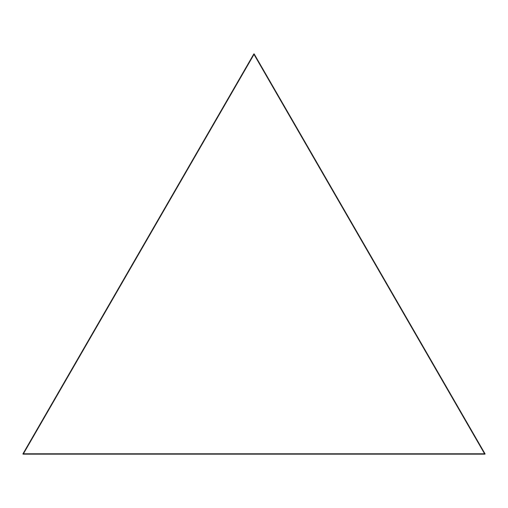

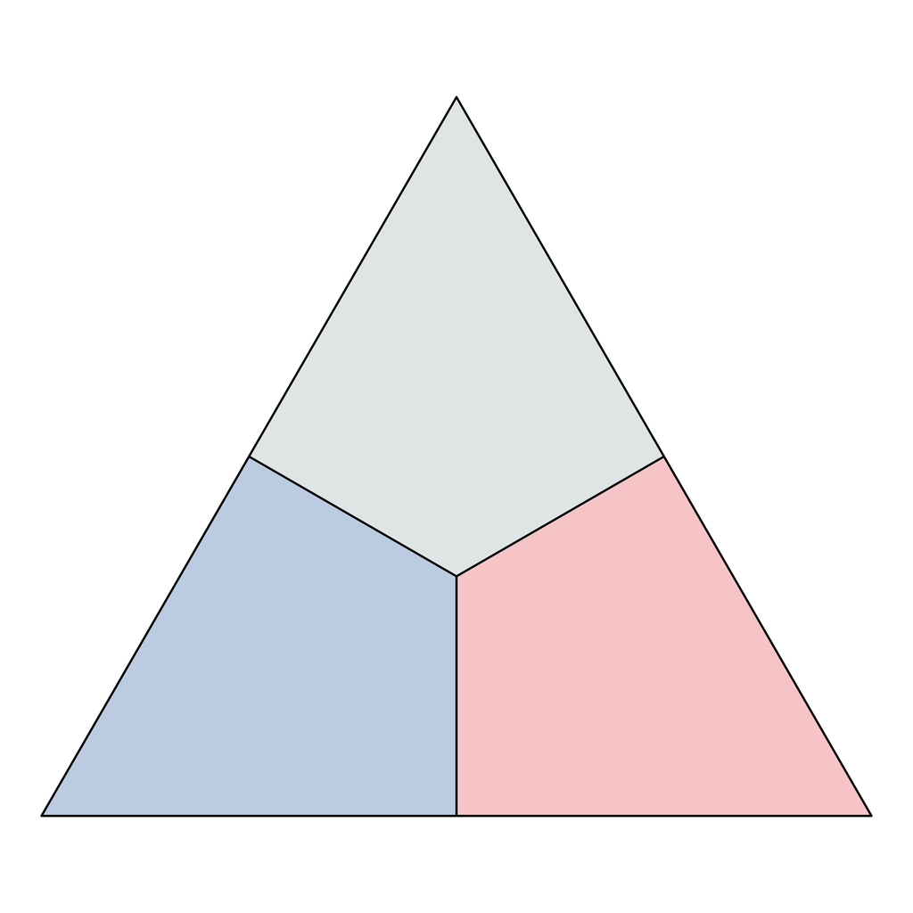

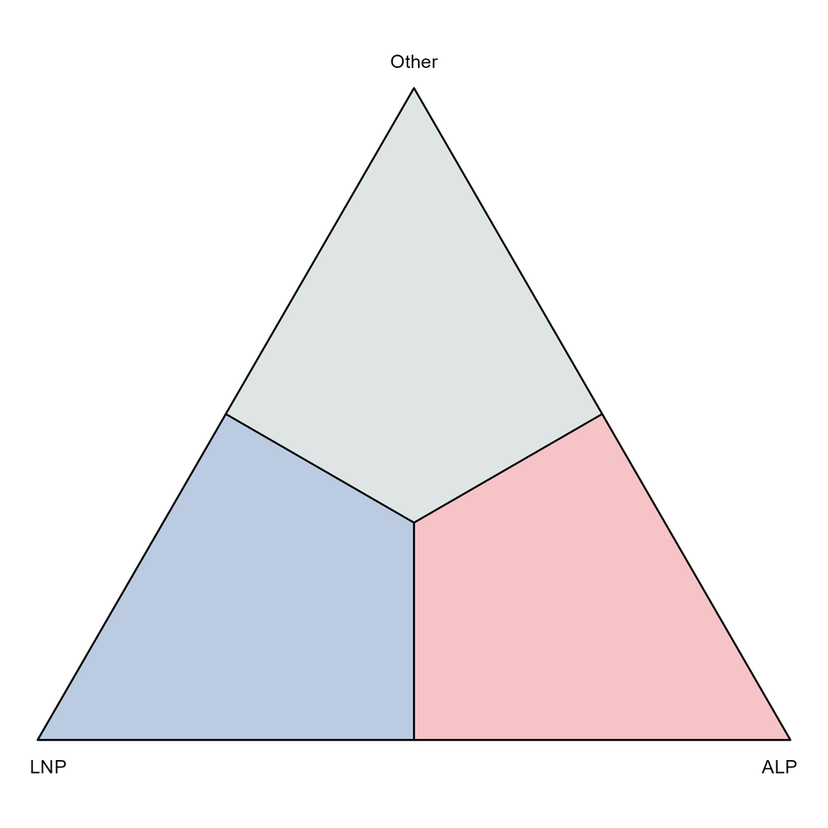

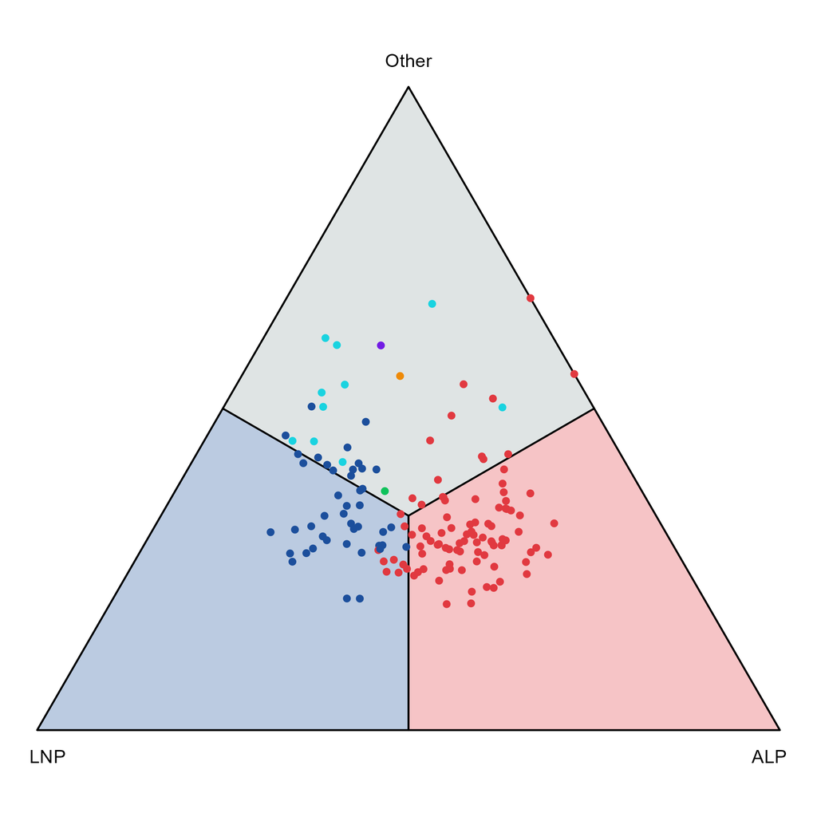

## How do preference shares shift through counting rounds?

```r
path_input <- input_data |>
  filter(DivisionNm %in% c("Fowler", "Melbourne", "Richmond")) |>
  mutate(text = paste0("Round: ", CountNumber, "\n", text))

ggplot(path_input, aes(x = x1, y = x2)) +
  ...
  stat_ordered_path(
    aes(group = DivisionNm, order_by = CountNumber, color = DivisionNm),
    linewidth = 0.5) +
  geom_point_interactive(aes(color = DivisionNm, tooltip = text, data_id = DivisionNm)) +
  ...
```

[interactive chart not shown]

## What additional structure is revealed when Greens and Independents are separated from “Others”?

- Plot
- Code

[interactive chart not shown]

```r
tern_hd <- as_ternable(
  pref25_hd_all |> filter(CountNumber == 0),
  items = c(ALP, LNP, GRN, IND, Other)
)

dtour_data <- get_tern_datahd(tern_hd) |>
  mutate(Winner = factor(coalesce(Winner, labels), levels = names(party_colors)))

detour(dtour_data,
       tour_aes(projection = x1:x4,
                colour = Winner,
                labels = text)) |>
  tour_path(planned_tour(lt), fps = 60) |>
  show_scatter(
    axes    = FALSE,
    palette = party_colors,
    edges   = get_tern_edges(tern_hd),
    size    = 1)
```

# Part 5

**More things you can do with `prefviz`**

## Distribution of preferences bar chart - `dop_bar`

```r
sushi_data <- prefio::read_preflib(
  "00014 - sushi/00014-00000001.soc",
  from_preflib = TRUE
)

irv_tbl <- dop_irv(
  sushi_data,
  value_type = "percent",
  preferences_col = preferences,
  frequency_col = frequency
)

dop_bar(irv_tbl, items = -c(round, winner), at_round = 1)
```

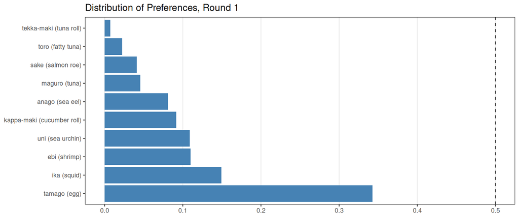

## Pairwise comparison — `pairwise_heatmap`

If we pick out 2 random items and look at their relative positions on the ballot, which one would win?

```r
sushi_data <- prefio::read_preflib(
  "00014 - sushi/00014-00000001.soc",
  from_preflib = TRUE
)

pw_result <- pairwise_calculator(
  sushi_data,
  preferences_col = preferences,
  frequency_col   = frequency
)

pairwise_heatmap(pw_result, value = "tcp")
```

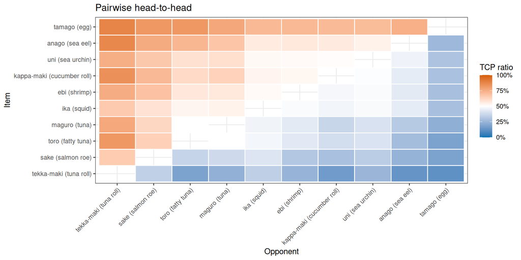

*Each cell shows the proportion of ballots that preferred row item over column item.*

## Limitations and Next steps

**Limitations**

- 2D plots lack visual aids such as axis ticks, reference lines, and axis labels to help orient the viewer
- Precise projections for HD plots to observe all pairwise compositions need mathematical computation

**Next steps**

- Website refresh for version 0.1.2
- Submit a software paper to *R Journal*

Thank you!

[figure not shown]

## Appendix 1: Project structure

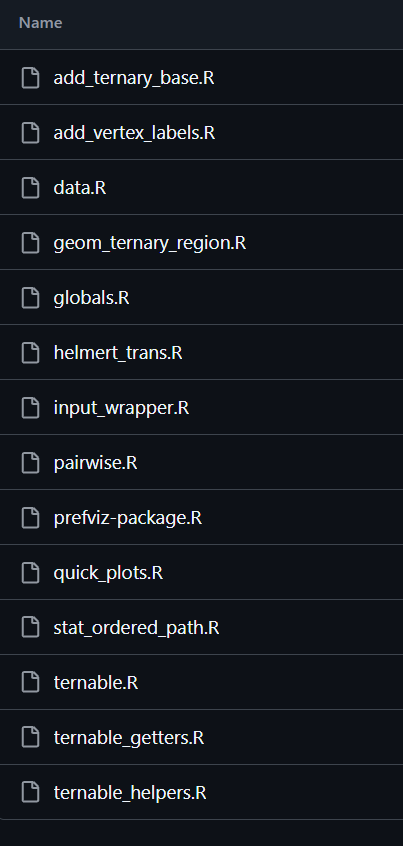

## Appendix 2: Main functions

| Function | Description |
| --- | --- |
| Ternable object |  |
| as_ternable(data, items) | Create a ternable object that stores all simplex components |
| get_tern_data2d(tern) | Extract 2D / HD projected coordinates |
| get_tern_edges(tern) | Get simplex edge pairs for tour overlays |
| get_tern_labels(tern) | Get vertex label strings |
| ggplot2 extensions for ternary plots |  |
| add_ternary_base() | Draw the triangle frame |
| geom_ternary_region(...) | Fill coloured regions per party |
| add_vertex_labels(vertices) | Add party labels at corners |
| stat_ordered_path(...) | Draw preference-flow paths |
| Election calculators |  |
| dop_irv(data, ...) | Compute IRV rounds from ranked ballots |
| pairwise_calculator(data, ...) | Compute all pairwise win proportions |
| Quick plots |  |
| dop_bar(irv_tbl, ..., at_round) | Bar chart of preference distribution at a round |
| pairwise_heatmap(pw, value) | Heatmap of two-candidate preferred margins |

## Appendix 3: `ternable` object

A `ternable` object contains the data and metadata necessary for ternary plots, including the **vertices, edges, labels** of the simplex, and **coordinates** of all data points.

```r
tern_2d <- as_ternable(pref25_2d, items = ALP:Other)
```

- **`ternary_coords`** - coordinates of all data points
- **`simplex_vertices`** - coordinates of the 3 corners
- **`simplex_edges`** - pairs connecting vertices
- **`vertex_labels`** - party names at each corner

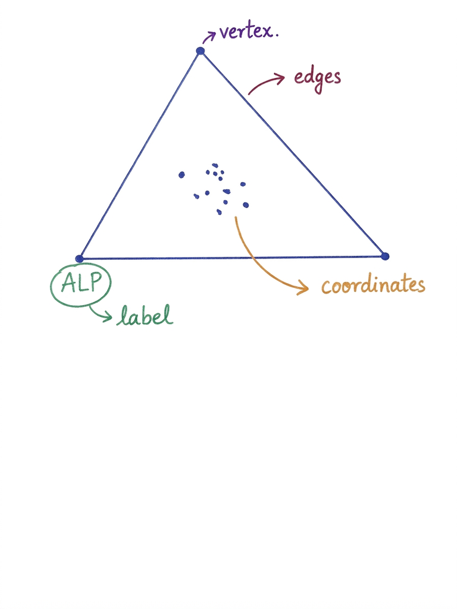